# ME414 - Estatística para Experimentalistas

## Qual a idade?

## Coleta de dados

Nessa atividade iremos apresentar a foto de dez (10) pessoas e cada aluno deverá tentar adivinhar a idade de cada uma dessas pessoas.

Para isso, os alunos devem fazer o seguinte:

1. Cada aluno deverá pegar uma folha de papel e recortá-la em 10 tiras.
2. Cada tira deverá ser identificada com Pessoa 1, Pessoa 2, …, Pessoa 10, que representará a pessoa apresentada na foto.
3. Ao lado da identificação da Pessoa, colocar um “chute” para a idade da pessoa.

**IMPORTANTE**: Não consulte seus colegas, coloque o seu “chute” sobre a idade.

## Pessoa 1

[figure not shown]

## Pessoa 2

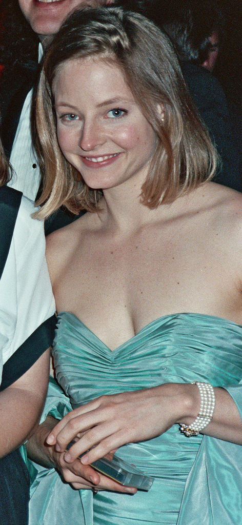

## Pessoa 3

[figure not shown]

## Pessoa 4

[figure not shown]

## Pessoa 5

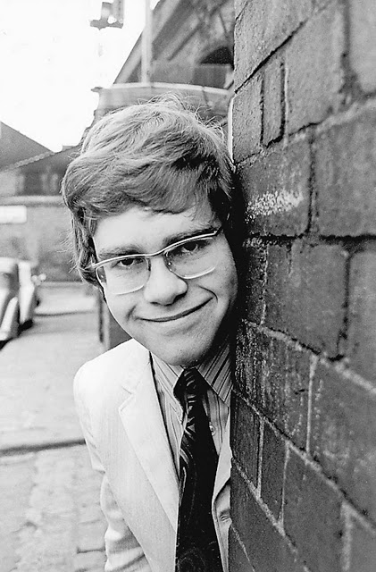

## Pessoa 6

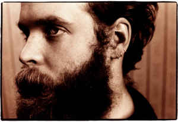

## Pessoa 7

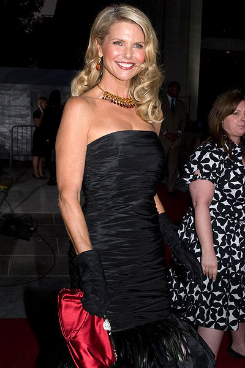

## Pessoa 8

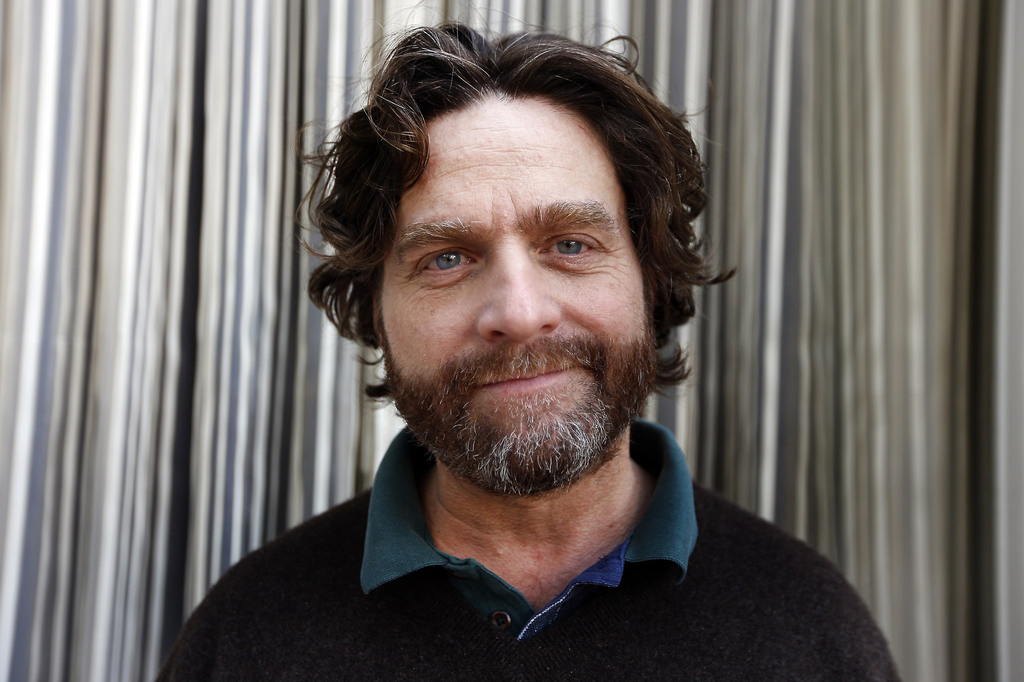

## Pessoa 9

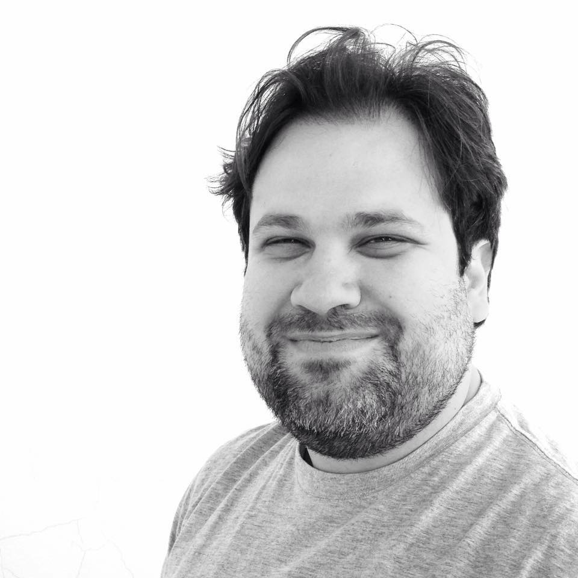

## Pessoa 10

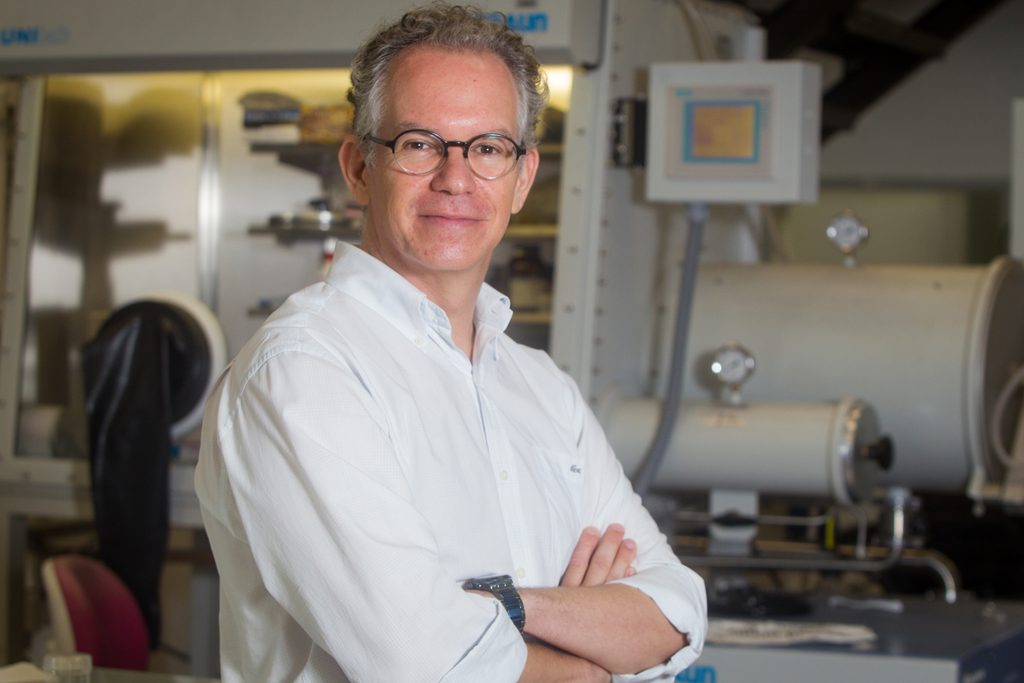

## Grupos

Formam-se 10 grupos (número de membros em cada grupo depende do número de alunos na sala).

Grupo X fica responsável por coletar os dados da Pessoa X, ou seja, as tiras de papel com os chutes da idade referentes à Pessoa X.

Cada grupo deve entregar uma folha com:

- Título: Pessoa X
- RA e nome de cada membro do grupo X

Depois de organizar os dados no papel, apresentar o seguinte:

1. estatísticas sumárias (mínimo, Q1, mediana, Q3, máximo, média, desvio padrão)
2. gráfico de ramo-e-folhas
3. histograma
4. boxplot

Baseando-se na análise descritiva realizada, apresente uma **estimativa para a idade da Pessoa X**.

A presença será contabilizada pela entrega dessa atividade ao final da aula.

Slides produzidos por:

- Samara Kiihl